# Stat 480 - Homework #7

Zahra Khoshmanesh

3/5/2020

#### Measles Vaccination Rates

1. Download the RMarkdown file with these homework instructions to use as a template for your work. Make sure to replace “Your Name” in the YAML with your name.
2. The data this week comes from [The Wallstreet Journal](https://github.com/WSJ/measles-data). The data set includes immunization rate data for schools across the U.S. The accompanying article is published [here](https://www.wsj.com/graphics/school-measles-rate-map/).

```r
library(dplyr)
library(ggplot2)
library(readr)
measles <- read_csv('https://raw.githubusercontent.com/rfordatascience/tidytuesday/master/data/2020/2020-02-25/measles.csv')
```

3. For how many schools do we have data? How many of these schools recorded their Measles, Mumps, and Rubella (MMR) vaccination rate? Use the variable `mmr` to answer this question. Only consider schools with a rate > 0 for the remainder of the homework.

If ignore duplicate records, we have :

```r
measles %>% count() # we have data for 66113 schools
```

```
## # A tibble: 1 x 1
##       n
##   <int>
## 1 66113
```

```r
measles %>% filter(mmr>0) %>% count() #44157 of schools recorded mmr rate if ignore duplicates
```

```
## # A tibble: 1 x 1
##       n
##   <int>
## 1 44157
```

Using distinct records, we have

```r
## your answer here
measles %>% distinct() %>% count() #if we use distinct rows it decreas to 65407
```

```
## # A tibble: 1 x 1
##       n
##   <int>
## 1 65407
```

```r
measles %>% distinct() %>%  filter(mmr>0) %>% count() #if we use distinct rows, it is 43503 records
```

```
## # A tibble: 1 x 1
##       n
##   <int>
## 1 43503
```

```r
#consider schools with a rate > 0 for the remainder of the homework
measles_data <- measles %>% filter(mmr>0)
```

4. Using `mutate()`, reorder the levels of the variable `state` according to the median MMR vaccination rate. Then “pipe” your results into ggplot and create box plots of MMR vaccination rates for each state. Map the variable `state` to `color`, include the parameter `show.legend = FALSE` within `geom_boxplot()`, and flip the coordinates. Interpret.

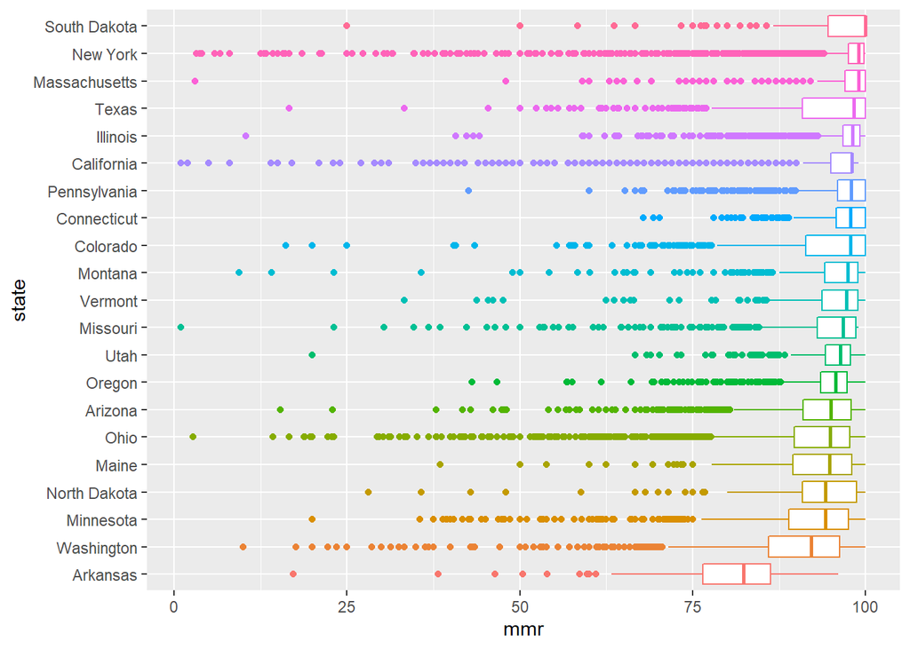

```r
## your answer here
measles_data %>% mutate(state=reorder(state, mmr,median)) %>%
  ggplot(aes(x=state,y=mmr,color=state))+
  geom_boxplot(show.legend = FALSE)+
  coord_flip()
```

**Interpret:** we can see that the boxplot arranged based on the median mmr.the state sorted decreasingly based on median state mmr rate.South dakota has the highest median mmr and arkansas has lowest median mmr rate.

5. According to the CDC, 95% of a population needs to be vaccinated to stop the spread of measles and preserve herd immunity. Using `mutate()` and `case_when()`, introduce a new variable into the data set `mmr_threshold` where the value is “above” when `mmr` is greater than 95 and “below” otherwise. Is there a relationship between the type of school and the proportion of schools that did not reach that threshold? For each type of school, calculate the mean MMR vaccination rate. On how many responses are the averages based? Show these numbers together with the averages. Additionally, calculate the percentage of schools that did not reach that threshold. Arrange your results from greatest percentage to lowest. Comment on your results.

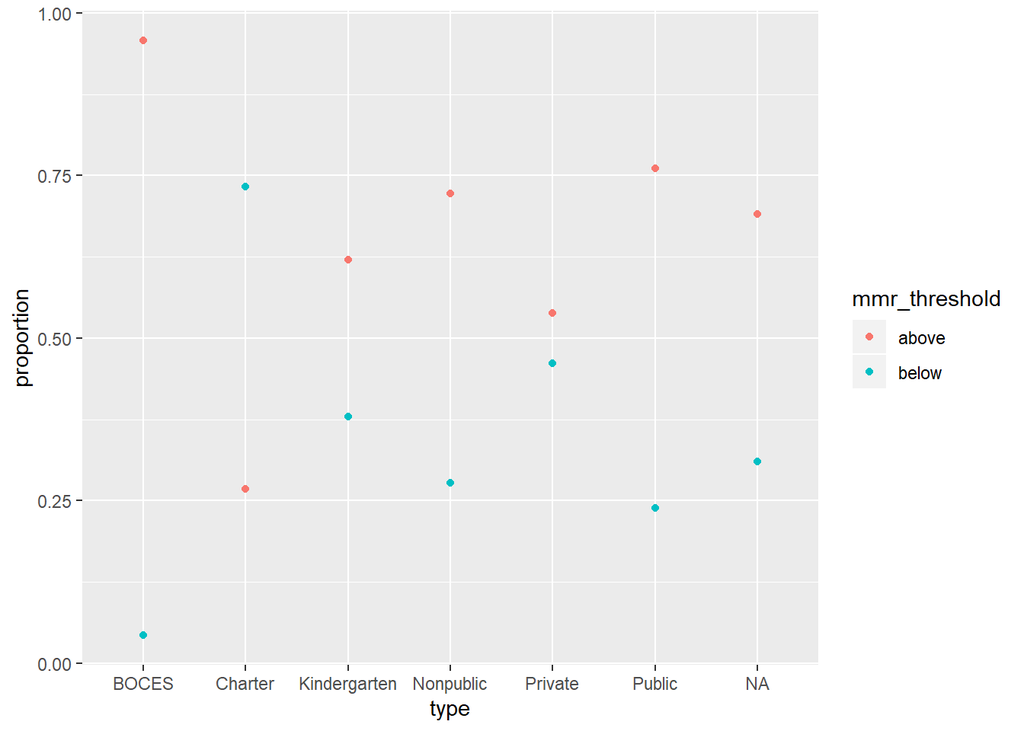

```r
## your answer here
measles_data <- measles_data %>% mutate(mmr_threshold=case_when(mmr >95 ~ "above",
                        mmr <=95  ~ "below"))

measles_data %>%
  select(type, mmr_threshold) %>%
  group_by(type, mmr_threshold) %>%
  summarise (n = n()) %>%
  mutate(proportion = n / sum(n)) %>%
  ggplot(aes(x=type,y=proportion,color=mmr_threshold))+
  geom_point()
```

Is there a relationship between the type of school and the proportion of schools that did not reach that threshold? yes, as we can see in the above plot, we can see the highest below threshold proportion is in Charter school. The highest above threshold belong to BOCES schools.

For each type of school, calculate the mean MMR vaccination rate. On how many responses are the averages based? Show these numbers together with the averages. Additionally, calculate the percentage of schools that did not reach that threshold. Arrange your results from greatest percentage to lowest. Comment on your results

```r
#For each type of school, calculate the mean MMR vaccination rate. On how many responses are the averages based?
measles_data %>%
  select(type,mmr,mmr_threshold) %>%
  group_by(type) %>%
  summarise(mean_mmr_rate=mean(mmr),responses_number=n())
```

```
## # A tibble: 7 x 3
##   type         mean_mmr_rate responses_number
##   <chr>                <dbl>            <int>
## 1 BOCES                 98.8               47
## 2 Charter               88.0              217
## 3 Kindergarten          94.2             1486
## 4 Nonpublic             94.4               18
## 5 Private               93.3             4597
## 6 Public                96.2            19762
## 7 <NA>                  94.5            18030
```

```r
#Additionally, calculate the percentage of schools that did not reach that threshold. Arrange your results from greatest percentage to lowest. Comment on your results
measles_data %>%
  select(type,mmr,mmr_threshold) %>%
  group_by(type,mmr_threshold) %>%
  summarise (n = n()) %>%
  mutate(percentage = n*100 / sum(n)) %>%
  filter(mmr_threshold=="below") %>%
  select(type,percentage) %>%
  arrange(desc(percentage))
```

```
## # A tibble: 7 x 2
## # Groups:   type [7]
##   type         percentage
##   <chr>             <dbl>
## 1 Charter           73.3
## 2 Private           46.2
## 3 Kindergarten      38.0
## 4 <NA>              31.0
## 5 Nonpublic         27.8
## 6 Public            23.9
## 7 BOCES              4.26
```

Comment on result: Charter has highest below percentage mmr rate. Boces hs lowest belo percentage rate.

6. Use `dplyr` functions to:
- only include observations with enrollment greater than 0 and exclude the school “West Valley School Prek-6” (there is an issue with that observation)
- filter for rows that have a unique combination of the variables `year`, `city`, `state`, name, `type`, `enroll`, and `mmr` (there are duplicates in the data)
- Inside `mutate()` use `weighted.mean()` to calculate the mean MMR vaccination rates weighted by the enrollment. Name this new variable `state_avg`.
- For each city and state combination, calculate the mean MMR vaccination rate weighted by enrollment, the total number of students enrolled, and the mean of the state average calculated in the previous step.
- only consider rows where the total enrollment is more than 250 and less than 100,000.

```r
## your answer here
question6_data <- measles_data %>%
  filter(enroll > 0, name!="West Valley School Prek-6") %>%  #enrollment greater than 0 and exclude the school "West Valley School Prek-6"
  distinct(year,city,state,name,type,enroll, mmr) %>%  #unique combination of the variables
  group_by(state) %>% #group for state
  mutate(state_avg=weighted.mean(mmr,enroll)) %>%  #calculate the mean MMR vaccination rates weighted by the enrollment
  ungroup() %>% #ungroup to access to other fields need to regroup for city
  group_by(state,city) %>% #For each city and state combination
  summarise(state_city_avg=weighted.mean(mmr,enroll),total_enrollment=sum(enroll),mean_state_avg=mean(state_avg)) %>%
  filter(total_enrollment >250, total_enrollment<100000) #consider rows where the total enrollment is more than 250 and less than 100,000.

question6_data
```

```
## # A tibble: 1,561 x 5
## # Groups:   state [15]
##    state   city          state_city_avg total_enrollment mean_state_avg
##    <chr>   <chr>                  <dbl>            <dbl>          <dbl>
##  1 Arizona Anthem                  86.5              259           93.2
##  2 Arizona Avondale                95.9             1254           93.2
##  3 Arizona Buckeye                 92.1             1115           93.2
##  4 Arizona Bullhead City           94.6              447           93.2
##  5 Arizona Casa Grande             96.0              706           93.2
##  6 Arizona Chandler                92.0             4120           93.2
##  7 Arizona Douglas                 96.8              342           93.2
##  8 Arizona El Mirage               96.0              398           93.2
##  9 Arizona Flagstaff               93.0              818           93.2
## 10 Arizona Florence                91.2              306           93.2
## # ... with 1,551 more rows
```

7. Now use the previous data set to draw a scatter plot with the mean MMR rate for each city on the y-axis and the student enrollment on the x-axis and color by the state mean MMR rate. Use the code below as your starting point and add in the necessary aesthetic mappings within `ggplot(aes( ))`. Describe and summarise the chart.

```
question6_data %>%
  ggplot(aes( )) +
  geom_hline(yintercept = 95, linetype = "dashed", size = 0.25, color = "grey40") +
  geom_point(size = 2, alpha = .3) +
  scale_color_gradient(low = "red", high = "blue", limits=c(88, 96), oob = scales::squish,
  guide = guide_colorbar(direction = "horizontal", title.position = "top",
                        title = "State average immunization rate", barwidth = 15, barheight = 0.25,
                        ticks = FALSE, title.hjust = 0.5)) +
  theme_minimal() +
  theme(legend.position = "bottom") +
  ggtitle("MMR immunization rates at schools grouped across US cities") +
  labs(subtitle="According to data collected by The Wall Street Journal",
       x = "Student Enrollment", y = "") +
  scale_x_continuous(labels = scales::comma)
```

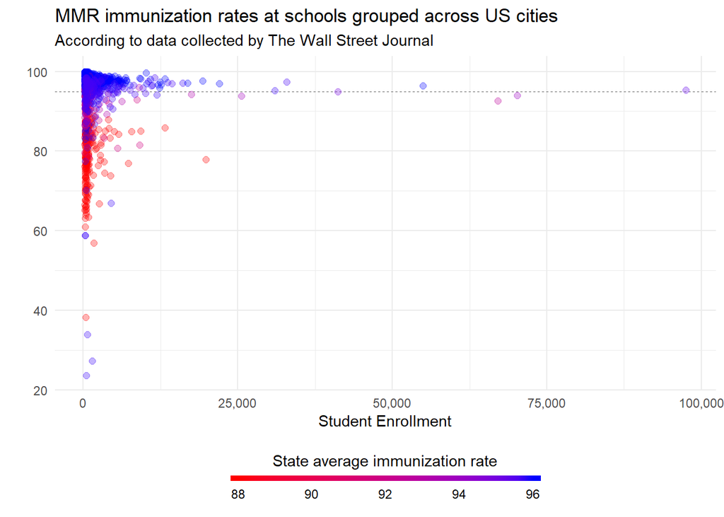

```r
## your answer here

question6_data %>%
  ggplot(aes(y=state_city_avg,x=total_enrollment,color=mean_state_avg )) +
  geom_hline(yintercept = 95, linetype = "dashed", size = 0.25, color = "grey40") +
  geom_point(size = 2, alpha = .3) +
  scale_color_gradient(low = "red", high = "blue", limits=c(88, 96), oob = scales::squish,
  guide = guide_colorbar(direction = "horizontal", title.position = "top",
                        title = "State average immunization rate", barwidth = 15, barheight = 0.25,
                        ticks = FALSE, title.hjust = 0.5)) +
  theme_minimal() +
  theme(legend.position = "bottom") +
  ggtitle("MMR immunization rates at schools grouped across US cities") +
  labs(subtitle="According to data collected by The Wall Street Journal",
       x = "Student Enrollment", y = "") +
  scale_x_continuous(labels = scales::comma)
```

Describe and summarize: majority of total enrollments per each city is less than 12000 and city has higher rate of mmr belong to state has higher mean mmr in that state. so we can conclude that higher mean state mmr rate indicate higher city mmr rate. Seems the lower city mmr rate belong to states has lower totall enrollment. the dashed line show the threshold (95)